# Elo and the EPL: a tutorial

The Elo rating system is a dynamically updated rating system originally created for chess by Arpad Elo that thrives in ranking head to head interactions with many iterations. By the end of this tutorial, any R user should be able to calculate the Elo score of any English Premier League Team during the course of any season, and have a basic understanding of how apply this technique to other leagues and sports.

### Let’s get started!

In broad strokes the steps to this analysis are:

1. Find and load data
2. Clean and format data
3. Apply Elo
4. Visualize results

Finding and Loading Data

Thankfully, [this website](http://www.football-data.co.uk/englandm.php) has an incredible amount of Premier League data. Download it to your working directoy below.

```r
download.file(url = "http://www.football-data.co.uk/mmz4281/1617/E0.csv", destfile = "epl1617.csv")
```

Your file is now downloaded. Use read.csv(), head(), and str() to check out the format and structure of the data.

```r
epl_1617 <- read.csv("epl1617.csv")
head(epl_1617)
```

|  | Div | Date | HomeTeam | AwayTeam | FTHG | FTAG | FTR | HTHG | HTAG | HTR | Referee | HS | AS | HST | AST | HF | AF | HC | AC | HY | AY | HR | AR | B365H | B365D | B365A | BWH | BWD | BWA | … |
| --- | --- | --- | --- | --- | --- | --- | --- | --- | --- | --- | --- | --- | --- | --- | --- | --- | --- | --- | --- | --- | --- | --- | --- | --- | --- | --- | --- | --- | --- | --- |
| 1 | E0 | 13/08/16 | Burnley | Swansea | 0 | 1 | A | 0 | 0 | D | J Moss | 10 | 17 | 3 | 9 | 10 | 14 | 7 | 4 | 3 | 2 | 0 | 0 | 2.40 | 3.3 | 3.25 | 2.45 | 3.1 | 2.95 | … |
| 2 | E0 | 13/08/16 | Crystal Palace | West Brom | 0 | 1 | A | 0 | 0 | D | C Pawson | 14 | 13 | 4 | 3 | 12 | 15 | 3 | 6 | 2 | 2 | 0 | 0 | 2.00 | 3.3 | 4.50 | 2.00 | 3.2 | 3.90 | … |
| 3 | E0 | 13/08/16 | Everton | Tottenham | 1 | 1 | D | 1 | 0 | H | M Atkinson | 12 | 13 | 6 | 4 | 10 | 14 | 5 | 6 | 0 | 0 | 0 | 0 | 3.20 | 3.4 | 2.40 | 2.95 | 3.2 | 2.40 | … |
| 4 | E0 | 13/08/16 | Hull | Leicester | 2 | 1 | H | 1 | 0 | H | M Dean | 14 | 18 | 5 | 5 | 8 | 17 | 5 | 3 | 2 | 2 | 0 | 0 | 4.50 | 3.6 | 1.91 | 4.33 | 3.4 | 1.90 | … |
| 5 | E0 | 13/08/16 | Man City | Sunderland | 2 | 1 | H | 1 | 0 | H | R Madley | 16 | 7 | 4 | 3 | 11 | 14 | 9 | 6 | 1 | 2 | 0 | 0 | 1.25 | 6.5 | 15.00 | 1.22 | 6.0 | 11.50 | … |
| 6 | E0 | 13/08/16 | Middlesbrough | Stoke | 1 | 1 | D | 1 | 0 | H | K Friend | 12 | 12 | 2 | 1 | 18 | 14 | 9 | 6 | 3 | 5 | 0 | 0 | 2.38 | 3.2 | 3.40 | 2.25 | 3.1 | 3.25 | … |

For the most basic application of Elo, we need to know what the result was (win, lose, draw), and who was playing. Let’s use dplyr’s handy case_when() function to quickly get our data in the correct format.

```r
library(dplyr)
epl_1617$winner = case_when(epl_1617$FTR == 'H' ~ as.character(epl_1617$HomeTeam),
                            epl_1617$FTR == 'A' ~ as.character(epl_1617$AwayTeam),
                            epl_1617$FTR == 'D' ~ as.character(epl_1617$HomeTeam))
epl_1617$loser = case_when(epl_1617$FTR == 'A' ~ as.character(epl_1617$HomeTeam),
                            epl_1617$FTR == 'H' ~ as.character(epl_1617$AwayTeam),
                            epl_1617$FTR == 'D' ~ as.character(epl_1617$AwayTeam))
epl_1617$Draw = case_when(epl_1617$FTR == "D" ~ TRUE,
                          epl_1617$FTR != "D" ~ FALSE)
head(epl_1617[,c('winner', 'loser', 'Draw')])
```

|  | winner | loser | Draw |
| --- | --- | --- | --- |
| 1 | Swansea | Burnley | FALSE |
| 2 | West Brom | Crystal Palace | FALSE |
| 3 | Everton | Tottenham | TRUE |
| 4 | Hull | Leicester | FALSE |
| 5 | Man City | Sunderland | FALSE |
| 6 | Middlesbrough | Stoke | TRUE |

This works quite well. For the package we’ll be using to calcualte elo (EloRating), we need a winner, loser, and a boolean column for a Draw in the next column. Also, if the Draw column is TRUE, it doesn’t matter who is in the winner column vs the loser so I just put the home team in the winning column and the away team in the losing column.

Now let’s filter for the columns we need and install/load the EloRating package.

```r
library(EloRating)
epl_1617_elo <- epl_1617[,c('Date', 'winner', 'loser', 'Draw')]
```

Currently the Date column is in the wrong format, and is a factor. Use subtring to get it in ‘year/month/date’ format and as.Date() to make R recognize it as a Date.

```r
epl_1617_elo$Date <- as.Date(epl_1617_elo$Date,"%d/%m/%Y")
epl_1617_elo$Date <- as.character(epl_1617_elo$Date)
substr(epl_1617_elo$Date, 1, 2) <- "20"
epl_1617_elo$Date <- as.Date(epl_1617_elo$Date)
head(epl_1617_elo)
```

|  | Date | winner | loser | Draw |
| --- | --- | --- | --- | --- |
| 1 | 2016-08-13 | Swansea | Burnley | FALSE |
| 2 | 2016-08-13 | West Brom | Crystal Palace | FALSE |
| 3 | 2016-08-13 | Everton | Tottenham | TRUE |
| 4 | 2016-08-13 | Hull | Leicester | FALSE |
| 5 | 2016-08-13 | Man City | Sunderland | FALSE |
| 6 | 2016-08-13 | Middlesbrough | Stoke | TRUE |

Now we have all the data in the right format. The function elo.seq returns an object with the calculated elo scores, with each team starting at 1000 points.

```r
res_elo <- elo.seq(winner = epl_1617_elo$winner, loser = epl_1617_elo$loser, Date = epl_1617_elo$Date, runcheck = TRUE, draw = epl_1617_elo$Draw, progressbar = FALSE)
summary(res_elo)
```

```
Elo ratings from 20 individuals
total (mean/median) number of interactions: 380 (38/38)
range of interactions: 38 - 38
date range: 2016-08-13 - 2017-05-21
startvalue: 1000
uppon arrival treatment: average
k: 100
proportion of draws in the data set: 0.22
```

It worked perfectly! We can use the eloplot() function to look at a time series calculation for each team.

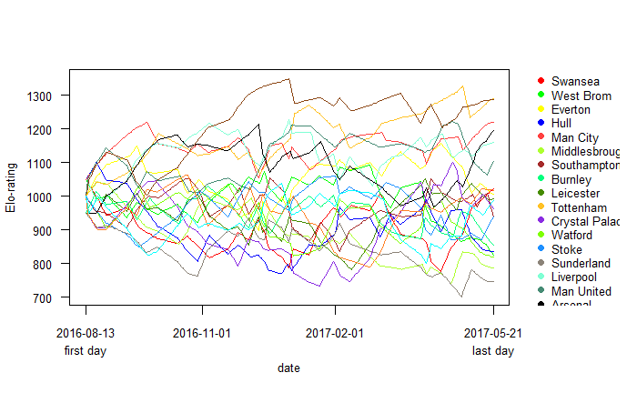

```r
eloplot(res_elo)
```

What a terrible visualization. We can do so much better. The res_elo$mat matrix has everything we’ll need. Turn it into a dataframe and then view.

```r
elo_totals <- res_elo$mat
elo_totals <- as.data.frame(elo_totals)
head(elo_totals)
```

|  | Swansea | West Brom | Everton | Hull | Man City | Middlesbrough | Southampton | Burnley | Leicester | Tottenham | Crystal Palace | Watford | Stoke | Sunderland | Liverpool | Man United | Arsenal | Bournemouth | Chelsea | West Ham |
| --- | --- | --- | --- | --- | --- | --- | --- | --- | --- | --- | --- | --- | --- | --- | --- | --- | --- | --- | --- | --- |
| 1 | 1050 | 1050 | 1000 | 1050 | 1050 | 1000 | 1000 | 950 | 950 | 1000 | 950 | 1000 | 1000 | 950 | NA | NA | NA | NA | NA | NA |
| 2 | NA | NA | NA | NA | NA | NA | NA | NA | NA | NA | NA | NA | NA | NA | 1050 | 1050 | 950 | 950 | NA | NA |
| 3 | NA | NA | NA | NA | NA | NA | NA | NA | NA | NA | NA | NA | NA | NA | NA | NA | NA | NA | 1050 | 950 |
| 4 | NA | NA | NA | NA | NA | NA | NA | NA | NA | NA | NA | NA | NA | NA | NA | NA | NA | NA | NA | NA |
| 5 | NA | NA | NA | NA | NA | NA | NA | NA | NA | NA | NA | NA | NA | NA | NA | NA | NA | NA | NA | NA |
| 6 | NA | NA | NA | NA | NA | NA | NA | NA | NA | NA | NA | NA | NA | NA | NA | NA | NA | NA | NA | NA |

This dataframe has each team’s Elo score by index where the index is related to the different gamedays in the Premier League. Note that not every team plays on the same day, so let’s add the dates to make visualization easier.

```r
dates <- res_elo$truedates
elo_totals$Dates <- dates
```

Now we have everything we need for a proper ggplot visualization. Next step is to install/load the ggplot package.

```r
library(ggplot2)
```

Now create a function for graphing each team’s performance throughout the year.

```r
plotting_elo <- function(team_name){
  filtered_data <- elo_totals[,c(team_name, "Dates")]
  filtered_data <- filtered_data[!is.na(filtered_data[,team_name]),]

  x <- ggplot(data = filtered_data, aes(x = Dates, y = filtered_data[,1])) +
    geom_line() +
    ggtitle((paste("2016-2017 EPL Season: ", team_name))) +
    labs(y = "Elo Score", x = "Date") +
    geom_point()
  return(x)
}
```

Let’s test it out with the winner of the 16/17 season, Chelsea.

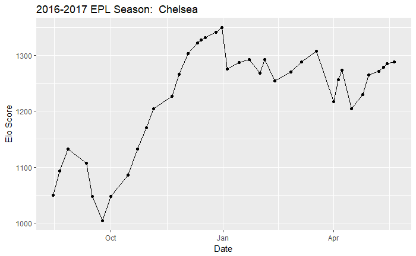

```r
Chelsea_elo <- plotting_elo("Chelsea")
Chelsea_elo
```

Now let’s check out the most continuously disappointing team in the league, Arsenal.

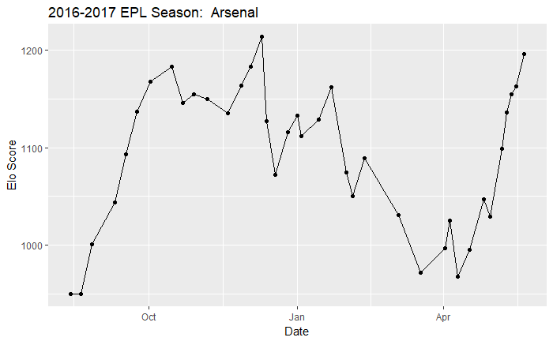

```r
Arsenal_elo <- plotting_elo("Arsenal")
Arsenal_elo
```

Arsenal managed to get almost to the 1200 Elo score with their late push for the Champion’s League spot but still ended far below the league champions.

How does the final Elo score compare to the final league ranking?

```r
final_elo <- as.data.frame(extract.elo(res_elo))
teams <- rownames(final_elo)
final_elo$Team <- teams
rownames(final_elo) <- NULL
ActualFinal <- c("Chelsea", "Tottenham", "Man City", "Liverpool", "Arsenal", "Man United", "Everton", "Southampton", "Bournemouth", "West Brom", "West Ham", "Leicester City", "Stoke City", "Crystal Palace", "Swansea City", "Burnley", "Watford", "Hull City", "Middlesbrough", "Sunderland")
final_elo$ActualResult <- ActualFinal
colnames(final_elo) <- c("Elo Score", "Team Name", "Actual Final")
final_elo
```

| Elo Score | Team Name | Actual Final |
| --- | --- | --- |
| 1290 | Tottenham | Chelsea |
| 1288 | Chelsea | Tottenham |
| 1221 | Man City | Man City |
| 1196 | Arsenal | Liverpool |
| 1161 | Liverpool | Arsenal |
| 1105 | Man United | Man United |
| 1022 | Swansea | Everton |
| 1018 | Bournemouth | Southampton |
| 1006 | Everton | Bournemouth |
| 993 | Leicester | West Brom |

[output cut: 10 more lines]

The Elo score seems to compare fairly well to the final rankings. Note that the goal was not to predict who would win the league, but to measure the skill of each team in comparison so we should not be worried with small errors like Arsenal and Liverpool being swapped.

If you have any questions or comments, please reach out to me here